# Practica 5:

Analisis descriptivo de datos

Emmanuel Garduño Téllez

Estadistica Comutacional

#personalizar nuestra seccion

```r
options(digits=3,papersize = "letter")
# https://stat.ethz.ch/R-manual/R-devel/library/base/html/options.html


# Opciones globales en graficas
par(mar=c(5.1,5,4.1,2.1),font=3,family="sans",bg="yellow")
```

TUTORIAL 5: MODELOS PROBABILÍSTICOS O ESTADÍSTICOS PROF. ELUZABETH MARTINEZ ESTADISTICA COMPUTACIONAL

Ver: https://rmarkdown.rstudio.com/authoring_basics.html

Un modelo probabilístico o estadístico es la forma que puede tomar un conjunto de datos (se supone que éstos provienen de muestreos aleatorios).

Un **modelo estadístico** es un tipo de modelo matemático que usa la probabilidad para describir de manera adecuada un conjunto de datos.

Un modelo estadístico queda especificado por un conjunto de ecuaciones que relacionan diversas variables aleatorias, y en las que pueden aparecer otras variables no aleatorias.

# 1 Modelos basados en distribuciones

Ver Tutorial 4.

# 2 Modelos de regresión

Un modelo estadístico de regresión es una expresión simbólica en forma de igualdad o ecuación que se emplea en todos los diseños experimentales y en la regresión para indicar los diferentes factores que modifican la variable de respuesta.

*Problema:*

*¿La inteligencia de una persona está determinada por el tamaño del cerebro basado en el conteo obtenido a partir de escaneos por resonancia magnética, MRI (cuentas/10,000) o por el de su cuerpo (estatura-pulgadas, peso-libras)?*

Repasemos cómo estimar e interpretar el **modelo de regresión lineal simple**.

## 2.1 Modelo de regresión lineal simple

```r
setwd("C:/Users/Emman/Documents/CCH-N} FES-A/fessaa/FES/7mo semestre/Temas Selectos de Estadistica")
inteligencia<- read.table("./DATA/Datos cerebroFile.txt",header=T,row.names=1);inteligencia
```

```
##            IQ Cerebro Altura Peso
## Luis      124    81.7   64.5  118
## Manuel    150   103.8   73.3  143
## Paco      128    96.5   68.8  172
## Andres    134    95.2   65.0  147
## Julio     110    92.9   69.0  146
## Ana       131    99.1   64.5  138
## Hugo       98    85.4   66.0  175
## Mariana    84    90.5   66.3  134
## Montse    147    95.5   68.8  172
## Candy     124    83.4   64.5  118
## Tomas     128   108.0   70.0  151
## Carlos    124    92.4   69.0  155
## Monica    147    85.7   70.5  155
## Beto       90    87.9   66.0  146
## Lupe       96    86.5   68.0  135
## Karla     120    85.2   68.5  127
## Mario     102    94.5   73.5  178
## Millie     84    80.8   66.3  136
## Maria      86    88.9   70.0  180
## Rafa       84    90.6   76.5  186
## Laura     134    79.1   62.0  122
## Toby      128    95.5   68.0  132
## Ale       102    83.2   63.0  114
## Ricardo   131    93.5   72.0  171
## Carolina   84    79.9   68.0  140
## Max       110   106.2   77.0  187
## Silvia     72    79.3   63.0  106
## Elias     124    86.7   66.5  159
## Diana     132    85.8   62.5  127
## Mimi      137    95.0   67.0  191
## Juan      110    99.8   75.5  192
## Jerry      86    88.0   69.0  181
## Guillermo  81    83.4   66.5  143
## Sofia     128    94.8   66.5  153
## Pedro     124    94.9   70.5  144
## Luz        94    89.4   64.5  139
## Linda      74    93.0   74.0  148
## Mauricio   89    93.6   75.5  179
```

```r
attach(inteligencia)
names(inteligencia)
```

```
## [1] "IQ"      "Cerebro" "Altura"  "Peso"
```

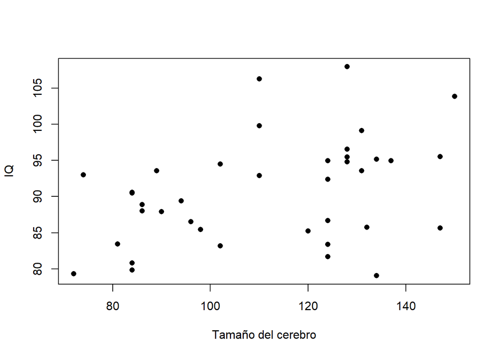

```r
plot(IQ,Cerebro,pch=16,xlab="Tamaño del cerebro",ylab="IQ")  # pueden cambiar el regresor X
```

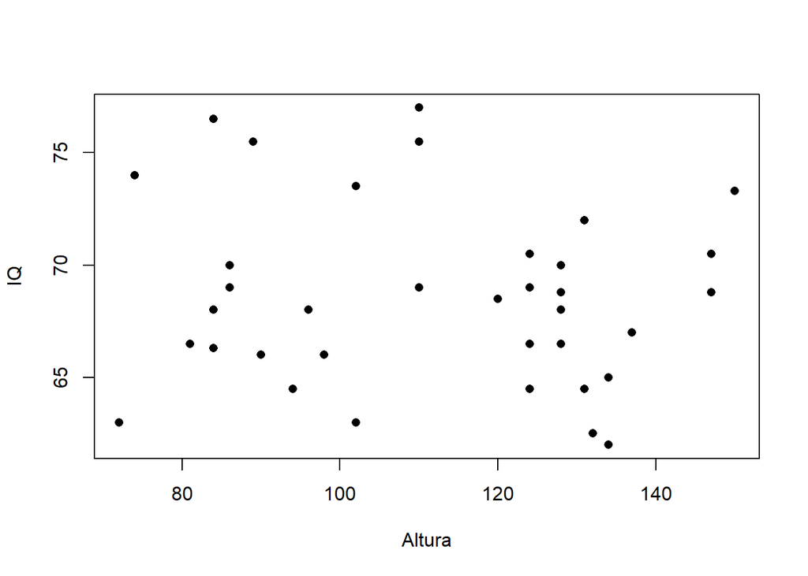

```r
plot(IQ,Altura,pch=16,xlab="Altura",ylab="IQ")
```

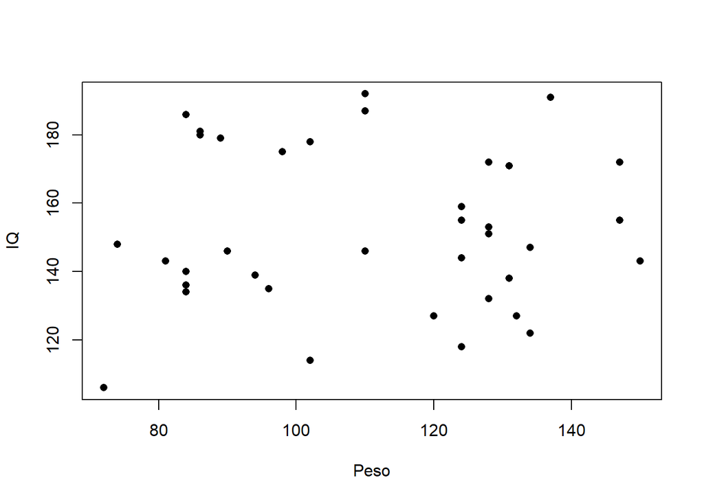

```r
plot(IQ,Peso,pch=16,xlab="Peso",ylab="IQ")
```

### 2.1.1 Estimación del modelo simple por MLE

Ver notas de clase para los estimadores.

```r
X<- Cerebro  # aqui cambien por otro regresor y observen los resultados
Y<- IQ

n<- length(X)

beta.hat<- (sum((X-mean(X))*(Y-mean(Y))))/sum((X-mean(X))^{2}); beta.hat
```

```
## [1] 1.18
```

```r
alpha.hat<- mean(Y)-beta.hat*mean(X); alpha.hat
```

```
## [1] 4.65
```

```r
sigma2.hat<- (1/n)*sum((Y-alpha.hat-beta.hat*X)^{2}); sigma2.hat
```

```
## [1] 426
```

```r
# Usando la funcion en R

plot(IQ,Cerebro, pch=16,xlab="Tamaño cerebro",ylab="IQ")  # ponerlo aqui de lo contrario marca error!

fit1<- lm(Y~X, data = inteligencia); fit1; summary(fit1)
```

```
##
## Call:
## lm(formula = Y ~ X, data = inteligencia)
##
## Coefficients:
## (Intercept)            X
##        4.65         1.18
```

```
##
## Call:
## lm(formula = Y ~ X, data = inteligencia)
##
## Residuals:
##    Min     1Q Median     3Q    Max
## -40.08 -17.51  -2.09  17.10  41.57
##
## Coefficients:
##             Estimate Std. Error t value Pr(>|t|)
## (Intercept)    4.652     43.712    0.11    0.916
## X              1.177      0.481    2.45    0.019 *
## ---
## Signif. codes:  0 '***' 0.001 '**' 0.01 '*' 0.05 '.' 0.1 ' ' 1
##
## Residual standard error: 21.2 on 36 degrees of freedom
## Multiple R-squared:  0.143,  Adjusted R-squared:  0.119
## F-statistic: 5.99 on 1 and 36 DF,  p-value: 0.0194
```

```r
abline(fit1,col="red")

fit2<- lm(Y~X-1, data = inteligencia); fit2; summary(fit2)
```

```
##
## Call:
## lm(formula = Y ~ X - 1, data = inteligencia)
##
## Coefficients:
##    X
## 1.23
```

```
##
## Call:
## lm(formula = Y ~ X - 1, data = inteligencia)
##
## Residuals:
##    Min     1Q Median     3Q    Max
## -40.17 -17.36  -2.07  16.94  41.86
##
## Coefficients:
##   Estimate Std. Error t value Pr(>|t|)
## X   1.2276     0.0373    32.9   <2e-16 ***
## ---
## Signif. codes:  0 '***' 0.001 '**' 0.01 '*' 0.05 '.' 0.1 ' ' 1
##
## Residual standard error: 20.9 on 37 degrees of freedom
## Multiple R-squared:  0.967,  Adjusted R-squared:  0.966
## F-statistic: 1.08e+03 on 1 and 37 DF,  p-value: <2e-16
```

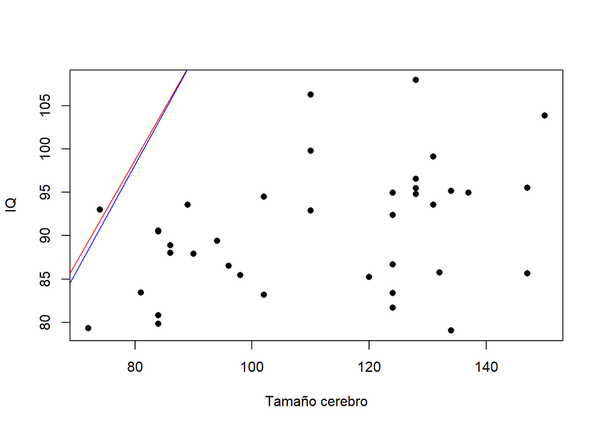

```r
abline(fit2,col="blue")
```

> *INTERPRETACION COEFICIENTE $\beta_{0}$*

> *Modelo con intercepto: en PROMEDIO, el IQ sube 4.652 independientemente del tamaño del cerebro.*

> *INTERPRETACION COEFICIENTE $\beta_{1}$*

> *Modelo con intercepto: por cada unidad adicional del tamaño del cerebro, el IQ cambia (por el signo positivo sube) en PROMEDIO, 1.177*

### Inferencia estadística sobre el modelo simple

#### Significancia estadística de los coeficientes del modelo

De la tabla de resultados analizamos los valores-p para cada coeficiente y realizamos el contraste de hipótesis:

H0: coeficiente=0 (no significativo)

Ha: coeficiente distinto de cero (significativo)

```r
library(broom)
glance(fit1)
```

```
## # A tibble: 1 x 12
##   r.squared adj.r.squared sigma statistic p.value    df logLik   AIC   BIC
##       <dbl>         <dbl> <dbl>     <dbl>   <dbl> <dbl>  <dbl> <dbl> <dbl>
## 1     0.143         0.119  21.2      5.99  0.0194     1  -169.  344.  349.
## # ... with 3 more variables: deviance <dbl>, df.residual <int>, nobs <int>
```

#### 2.1.1.1 Estimación de intervalos de confianza para los regresores

```r
ic1<- confint(fit1, level=0.95); ic1
```

```
##               2.5 % 97.5 %
## (Intercept) -84.000  93.30
## X             0.202   2.15
```

> *INTERPRETACION INTERVALO DE CONFIANZA PARA $\beta_{0}$*

> *Podemos afirmar con un nivel de confianza del 95% que, independientemente del tamaño del cerebro (medido en cuentas/10000), el IQ en PROMEDIO estará entre -83.99 y 93.30 (es claro, que los valores negativos no tienen sentido en este problema).*

> *INTERPRETACION INTERVALO DE CONFIANZA PARA $\beta_{1}$*

> *Podemos afirmar con un nivel de confianza del 95% que, ante un aumento del tamaño del cerebro (medido en cuentas/10000), el IQ en PROMEDIO subirá (por el signo positivo) entre 0.2019 y 2.1512*

### 2.1.2 Diagnóstico del modelo: Verificación de supuestos en R

1. Residuos vs valores ajustados (predichos). IDEAL: puntos aleatorios
2. Grafica QQ. IDEAL: La distribución de los ERRORES debería caer sobre la recta para decir que se distribuyen normalmente.
3. Escala-Localización. IDEAL: puntos aleatorios. No patrones.
4. Distancia de Cook: indica cuáles puntos tienen una fuerte influencia sobre la regresión (“leverage points”).

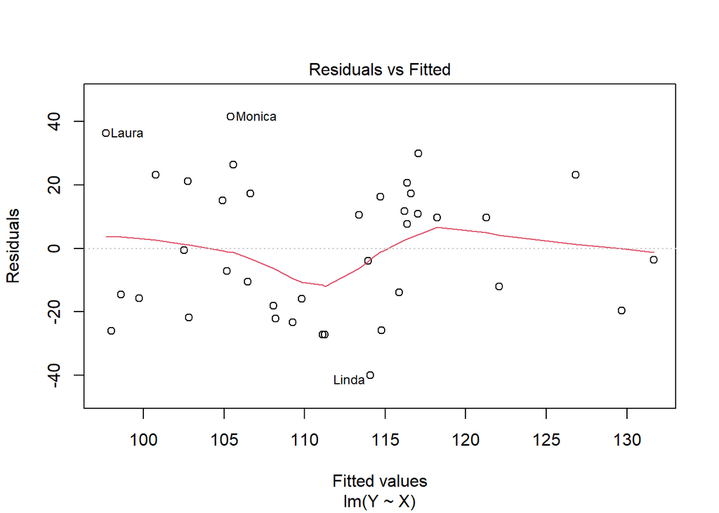

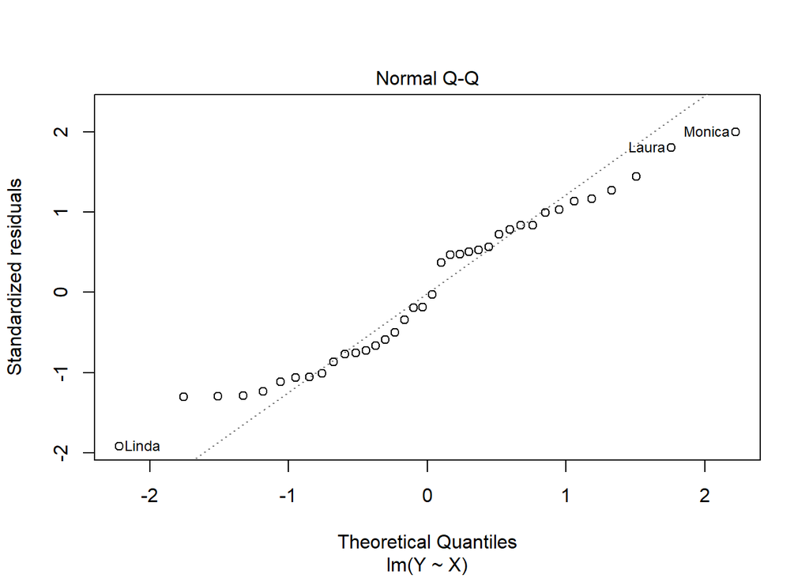

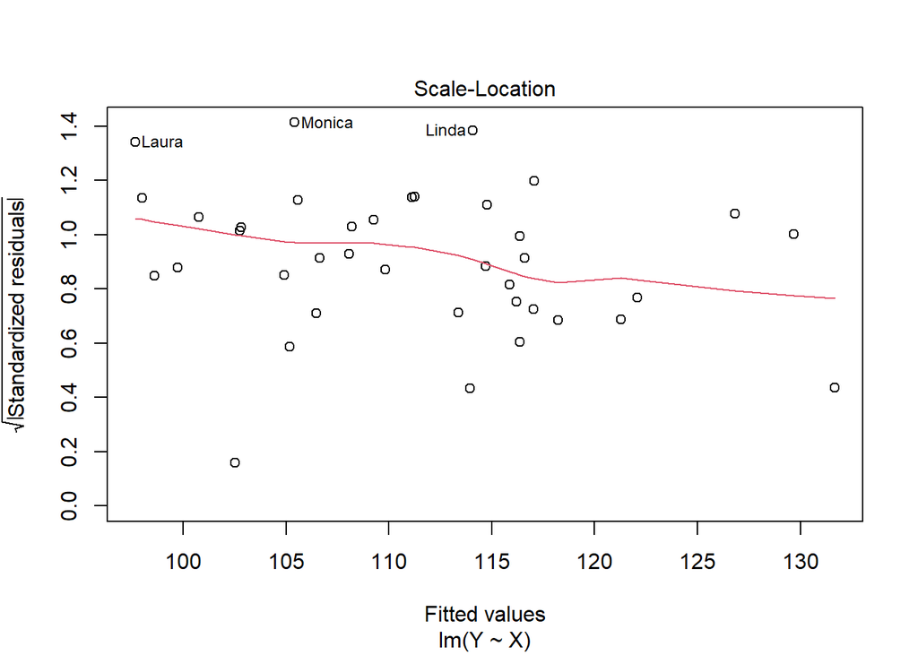

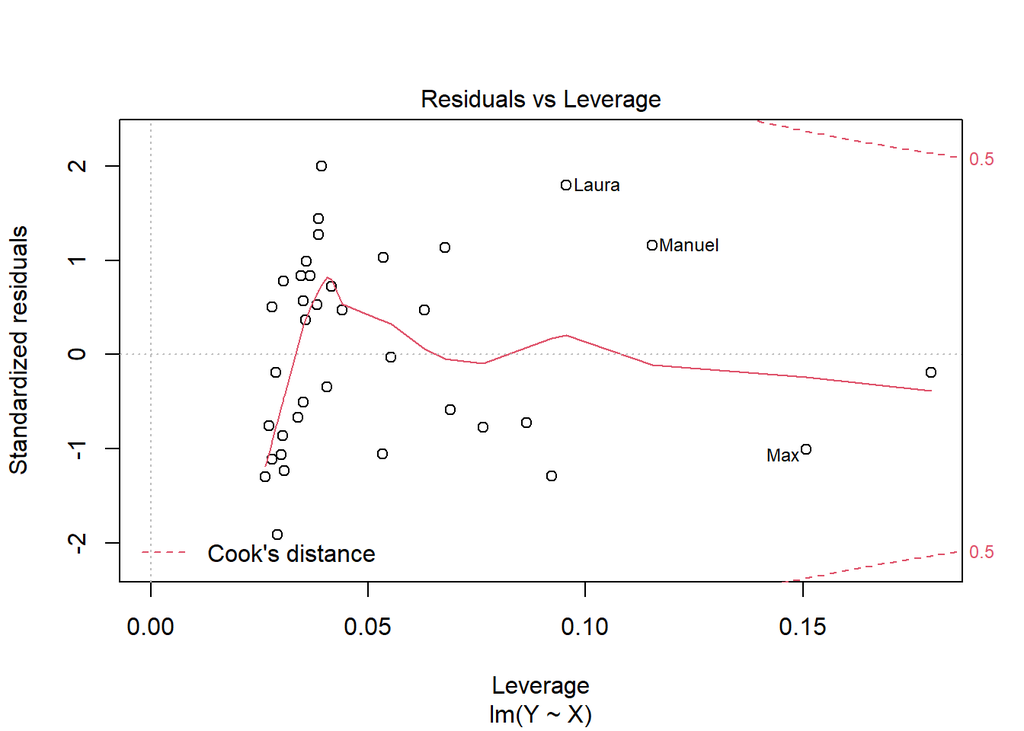

```r
plot(fit1)
```